```python
intro_images_path='../dataset_part1/Images/Intro_images/'
edge_images_path='../dataset_part1/Images/Edge_images/'
seg_images_path='../dataset_part1/Images/Seg_images/'
feature_images_path='../dataset_part1/Images/Feature_images/'
output_path='./Images/Outputs/'
print('Image paths ....')
```

```
Image paths ....
```

# COMPUTER VISION I

**Master in Artificial Intelligence, USC, UDC, UVigo**

Academic year 2023/24

[figure not shown]

#### EXERCISE 1

1. Select the best values for threshold1, threshold2, and gaussian sigma, for each of the following images: chuvia.jpg, xardin.jpg, paseo.jpg.
2. Simple methods as: (1) computing the median gray-level values and determine high and low thresholds as simmetric values around the median; (2)thresholds based on the maximum of the gradient; (3) ....; work well depending on the image context.

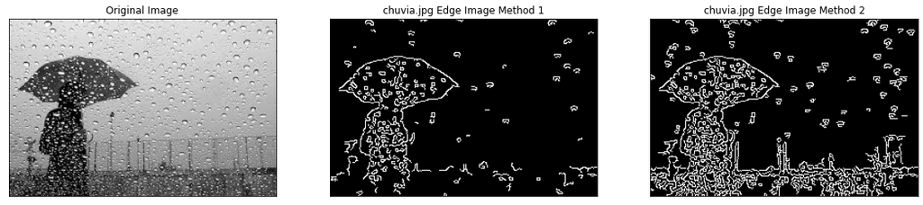

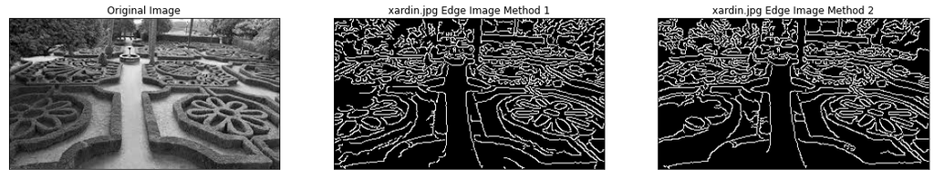

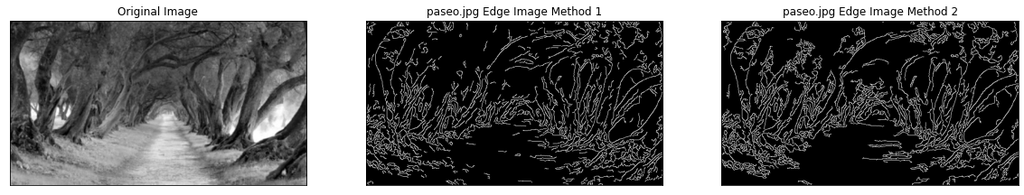

```python
#SOLUTION HERE
import cv2
import numpy as np
from matplotlib import pyplot as plt


paths=["chuvia.jpg","xardin.jpg","paseo.jpg"]

for path in paths:
    image = cv2.imread(edge_images_path+path,0)


    ###Method 1: Compute the median gray-level value
    mediana = np.median(image)
    # Define thresholds method 1
    umbral_inferior = int(max(0, 0.7 * mediana))
    umbral_superior = int(min(255, 1.3 * mediana))

    # Apply GaussianBlur
    imagen_suavizada = cv2.GaussianBlur(image, (5, 5), 0)

    # Apply Canny for method 1
    edges1 = cv2.Canny(imagen_suavizada, umbral_inferior, umbral_superior)

    # Method 2: Compute maximum gradient value
    gradiente_x = cv2.Sobel(image, cv2.CV_64F, 1, 0, ksize=3)
    gradiente_y = cv2.Sobel(image, cv2.CV_64F, 0, 1, ksize=3)
    magnitud_gradiente = np.sqrt(gradiente_x**2 + gradiente_y**2)

    # Define thresholds method 2
    umbral_superior = int(0.2 * np.max(magnitud_gradiente))
    umbral_inferior = int(0.05 * umbral_superior)

    # Apply Canny for method 2
    edges2 = cv2.Canny(imagen_suavizada, umbral_inferior, umbral_superior)

    plt.figure(figsize=(20, 20))
    plt.subplot(131),plt.imshow(image,cmap = 'gray')
    plt.title('Original Image'), plt.xticks([]), plt.yticks([])
    plt.subplot(132),plt.imshow(edges1,cmap = 'gray')
    plt.title(path+' Edge Image Method 1'), plt.xticks([]), plt.yticks([])
    plt.subplot(133),plt.imshow(edges2,cmap = 'gray')
    plt.title(path+' Edge Image Method 2'), plt.xticks([]), plt.yticks([])
    plt.show()
```

The second method consists of calculating the thresholds from the maximum of the image gradient. For this we calculate the gradient with the function cv2.Sobel() and once calculated, we multiply for a reduction and enlargement factor to create the thresholds that will then be applied to the Canny filter.

#### EXERCISE 2

Compare the following two template matching alternatives regarding their performance : (i) case of using image intensity as features for matching, and (ii) case of using their edge maps as features. Use faces.jpg and two different templates right_eye.jpg and right_eye_i.jpg. You will have to compute their edge maps to perform the matching in case (ii).

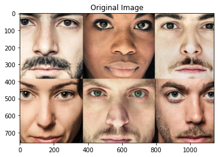

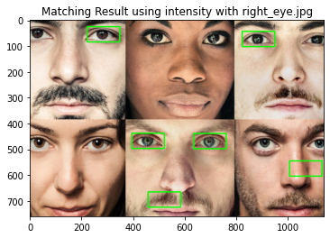

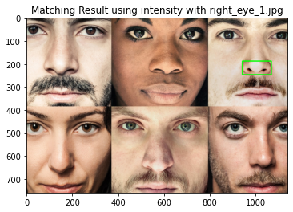

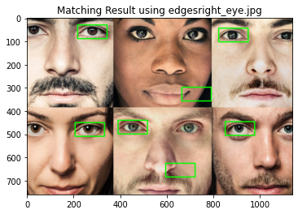

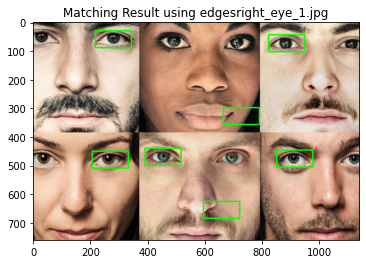

```python
import cv2
import numpy as np
import matplotlib.pyplot as plt

#Function for matching using intensity
def match_using_intensity(img, template):
    result = cv2.matchTemplate(img, template, cv2.TM_CCOEFF_NORMED)
    _, max_val, _, max_loc = cv2.minMaxLoc(result)
    return max_val,max_loc

#Function for matching using edges
def match_using_edges(img, template):
    # Calculate image gradient
    gradiente_x = cv2.Sobel(img, cv2.CV_64F, 1, 0, ksize=3)
    gradiente_y = cv2.Sobel(img, cv2.CV_64F, 0, 1, ksize=3)
    magnitud_gradiente = np.sqrt(gradiente_x**2 + gradiente_y**2)
    #Apply GaussianBlur
    imagen_suavizada = cv2.GaussianBlur(img, (5, 5), 0)
    template_suavizada = cv2.GaussianBlur(template, (7, 7), 0)
    # Define thresholds for image
    umbral_superior = int(0.3 * np.max(magnitud_gradiente))
    umbral_inferior = int(0.05 * umbral_superior)

    # Apply Canny for image
    img_edges = cv2.Canny(imagen_suavizada, umbral_inferior, umbral_superior)

    #Calculate template gradient
    gradiente_x = cv2.Sobel(template, cv2.CV_64F, 1, 0, ksize=3)
    gradiente_y = cv2.Sobel(template, cv2.CV_64F, 0, 1, ksize=3)
    magnitud_gradiente = np.sqrt(gradiente_x**2 + gradiente_y**2)

    # Define thresholds for template
    umbral_superior = int(0.35 * np.max(magnitud_gradiente))
    umbral_inferior = int(0.2 * umbral_superior)

    # Apply Canny for template
    template_edges = cv2.Canny(template_suavizada, umbral_inferior, umbral_superior)

    # Match using edges
    result = cv2.matchTemplate(img_edges, template_edges, cv2.TM_CCOEFF_NORMED)
    _, max_val, _, max_loc = cv2.minMaxLoc(result)
    return max_val,max_loc

# Load image and template
image = cv2.imread(edge_images_path+'faces.jpg',cv2.IMREAD_COLOR)
template1 = cv2.imread(edge_images_path+'right_eye.jpg')
template2 = cv2.imread(edge_images_path+'right_eye_i.jpg')
templates=[template1,template2]
# Show original image
plt.imshow(cv2.cvtColor(image,cv2.COLOR_BGR2RGB))
plt.title('Original Image')
plt.show()

# Show matching results
image_names=['right_eye.jpg','right_eye_1.jpg']
j=0
# Match using edges
for template in templates:
    # Match using
    img=image.copy()
    image2=image.copy()
    rectangles=[]
    #Make a loop to find all the matches
    while True:
        #Match using edges
        max_val,loc1_intensity = match_using_intensity(img, template)
        # Get the size of the template. Ignore the 3rd value returned by shape
        w, h = template1.shape[:2]
        top_left = loc1_intensity
        bottom_right = (top_left[0] + h, top_left[1] + w)
        #Create a rectangle
        rectangle=(top_left,bottom_right)
        #Add the rectangle to the list
        rectangles.append(rectangle)
        #If the max_val is less than 0.145, we stop the loop
        if max_val<0.52:
            break
        #If not, we set the area of the image where the rectangle is to 0
        img[top_left[1]:bottom_right[1], top_left[0]:bottom_right[0]] = 0

    #Show the image with the rectangles
    for i in range(len(rectangles)):
        #Draw the rectangle
        cv2.rectangle(image2, rectangles[i][0], rectangles[i][1], (0, 255, 0), 4)
    #Show the image
    plt.imshow(cv2.cvtColor(image2, cv2.COLOR_BGR2RGB))
    plt.title('Matching Result using intensity with '+image_names[j])
    plt.show()
    j+=1



j=0
# Match using edges
for template in templates:
    # Match using
    img=image.copy()
    image2=image.copy()
    rectangles=[]
    #Make a loop to find all the matches
    while True:
        #Match using edges
        max_val,loc1_intensity = match_using_edges(img, template)
        # Get the size of the template. Ignore the 3rd value returned by shape
        w, h = template1.shape[:2]
        top_left = loc1_intensity
        bottom_right = (top_left[0] + h, top_left[1] + w)
        #Create a rectangle
        rectangle=(top_left,bottom_right)
        #Add the rectangle to the list
        rectangles.append(rectangle)
        #If the max_val is less than 0.145, we stop the loop
        if max_val<0.145:
            break
        #If not, we set the area of the image where the rectangle is to 0
        img[top_left[1]:bottom_right[1], top_left[0]:bottom_right[0]] = 0

    #Show the image with the rectangles
    for i in range(len(rectangles)):
        #Draw the rectangle
        cv2.rectangle(image2, rectangles[i][0], rectangles[i][1], (0, 255, 0), 4)
    #Show the image
    plt.imshow(cv2.cvtColor(image2, cv2.COLOR_BGR2RGB))
    plt.title('Matching Result using edges'+image_names[j])
    plt.show()
    j+=1
```

When applying the template detection on the image, we see that if we use the intensity as detector, only for right_eye.jpg we get good results because right_eye_1.jpg is in BGR format, and therefore the intensities are upside down so we do not get to detect any eye. However, using edges as detectors we do get the same results for both images, since we are applying a Guassian filter and then the edge detector, so the color space in which the image is located does not influence.

The detection using edges that has been implemented consists of applying a Gaussian filter and then the Canny edge detector to both the image and the template in order to obtain the edges. For this process it was necessary to adjust this Gaussian filter and Canny's filter to detect the edges of the eyes but not to detect the rest of the facial features such as the beard. By eliminating these unnecessary facial features, the detection of the eyes is possible. Even so, we have not been able to detect all eyes. The eyes that are on the edge of the image are not detected because they are half cut and when applying the filter the complete shape of the eye is not obtained. Finally, in the center of the figure I have not been able to adjust correctly the values of the edge detection filter so that all eyes can be detected, because every time I varied some parameter I lost detections, and the maximum I have been able to detect is 5 eyes.